# Simulation Experiments

Andrea Brizzi

16/03/2021

## Settings

The objective of this html report is to document the results of each simulation. Here we define the settings of each simulation.

This time, we assume fixed $R_0 = $ 3` and assume an ideal scenario with reporting fraction of $100 \%$.

```r
gen_interval <- 7
R_0 = params$R0

simulations <- simulate_seir_stochastic(N = params$n_sims,
                                        arnaught = R_0,
                                        gamma = 1/3, sigma = 1/3.5,
                                        Reporting_fraction = 1,
                                        min_peak = 0)
# In case we would like to simulate something that looks more like COVID, it would
# make more sense to take a look at daily incidence, and modify quite a few things.
```

We fit all different models assuming a gamma generation interval distribution with mean 6.5 days and standard deviation of 0.62 days, as in Flaxman et al.

```r
GTd <- R0::generation.time("gamma", c(6.5, 0.62))
```

## R estimates

Now that we only have one level of noise, we don’t have to go over a threefold loop.

In this experiment, I wanted to look at the effect of missed generations. To do so, I firstly simulate the data as in Megan’s paper, and then trim off them the data for 0, 1, 2 generation intervals. I fit the methods to each of these dataset and hopefully get some results later on.

```r
# list to store results from simulations
Sim_results <- list()


for (gen in 0:params$missed_gens){
    # Missed generations parameter

    results_gen <- list()


  # for each of the simulations
  for(j in 1:ncol(simulations$sims)){

    # data for fitting - simulation j with noise level i
    sim_j <- data.frame(day = 1:nrow(simulations[[1]]), cases=simulations[[1]][ ,j],
                         country=paste("sim", j, sep='_'))

    # cut out the first n_generations
    sim_j_gen <- sim_j %>% filter(day > gen_interval * gen)

    # start from first observations:
    sim_j_gen <- filter(sim_j_gen, cumsum(cases) > 0)



    if(dim(sim_j_gen)[1] != 0){

      # fit & store results
      results_gen[[j]] <- fit_R0_seq(data=sim_j_gen,
                          mean_GT=6.5, sd_GT=0.62, GTd=GTd, GT_days=7,
                          methods = params$methods)

    }

  }

    #store results from each missed_gen cut off
    Sim_results[[gen + 1]] <- results_gen

  }
```

At the moment I cannot seem to have EG_MLE working. WHY? Is it really important?

## Results

We now want to study the impact of having missed the first generations of infections. Does this affect the estimate of $R_t$? Does this affect the uncertainty around the estimates?

To do, let us first detect all the simulations for which we are able to produce estimates for 0, 1 and 2 missed generations (note that we report the `i` as well to distinguish between the above types). \

```r
first_predictions <- data.frame()
indices = c()

# For each simulation
for (i in 1: length(Sim_results[[3]])){

  # if we are able to obtain estimates with 2 missed generations
  if (! is.null(Sim_results[[3]][[i]])){

    indices = c(indices, i)

    # attach first predictions when we don't miss any data
    tmp <- as.data.frame(Sim_results[[1]][[i]])
    tmp <- filter(tmp, `#GTofData` == 2)
    tmp$missed_gens <- 0
    first_predictions = rbind(first_predictions, tmp)

    # attach first predictions when we miss 1 week
    tmp <- as.data.frame(Sim_results[[2]][[i]])
    tmp <- filter(tmp, `#GTofData` == 2)
    tmp$missed_gens <- 1
    first_predictions = rbind(first_predictions, tmp)

    # attach first predictions when we miss 2 weeks
    tmp <- as.data.frame(Sim_results[[3]][[i]])
    tmp <- filter(tmp, `#GTofData` == 2)
    tmp$missed_gens <- 2
    first_predictions = rbind(first_predictions, tmp)

  }
}
rownames(first_predictions) <- NULL
```

We have a sample size of 250 obtained with 250 trials.

### Boxplots of R0_estimates

What do we expect in a scenario with 100 % reporting rate? There may be a tradeoff between more data for more missed generation vs better assumptions for no missing gens.

Now, we want to compare how our estimates of $R_0$ change for each method

```r
first_predictions$R0 <- as.numeric(first_predictions$R0)
first_predictions$Ndays <- as.numeric(first_predictions$Ndays)
sort(unique(first_predictions$Ndays))
```

```
## [1] 15 16 17 22 29
```

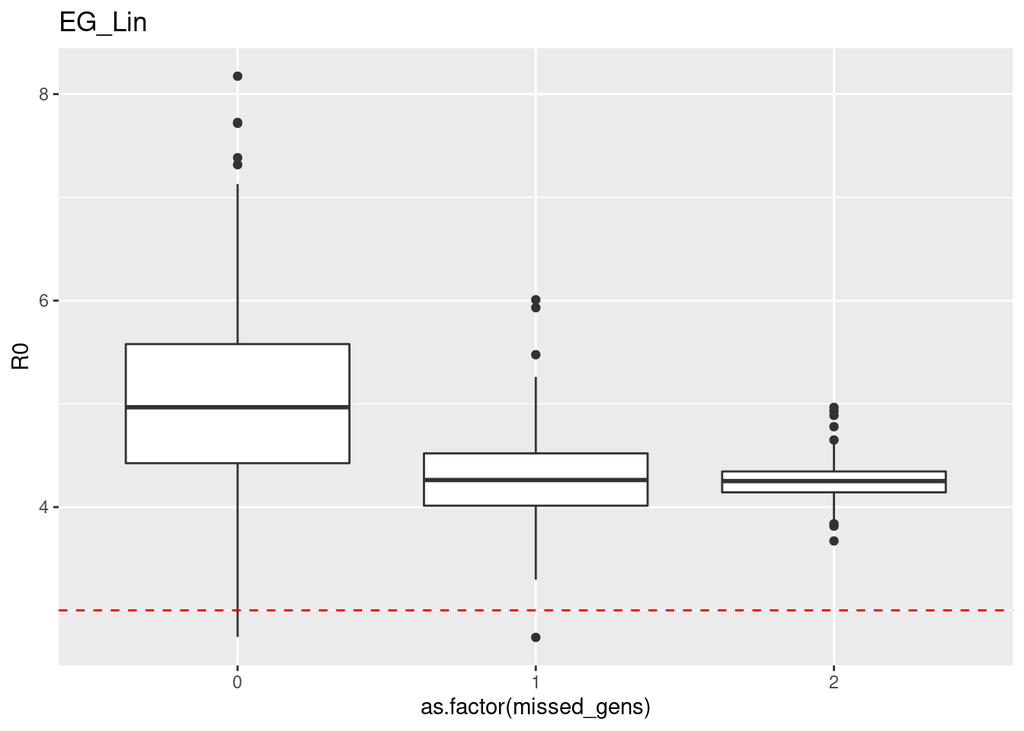

```r
df_eglin <- filter(first_predictions, method == "EG_Lin")
ggplot(df_eglin, aes(x = as.factor(missed_gens), y = R0)) + ggtitle("EG_Lin") +
  geom_boxplot() + geom_hline(yintercept = R_0, colour = "red", linetype="dashed")
```

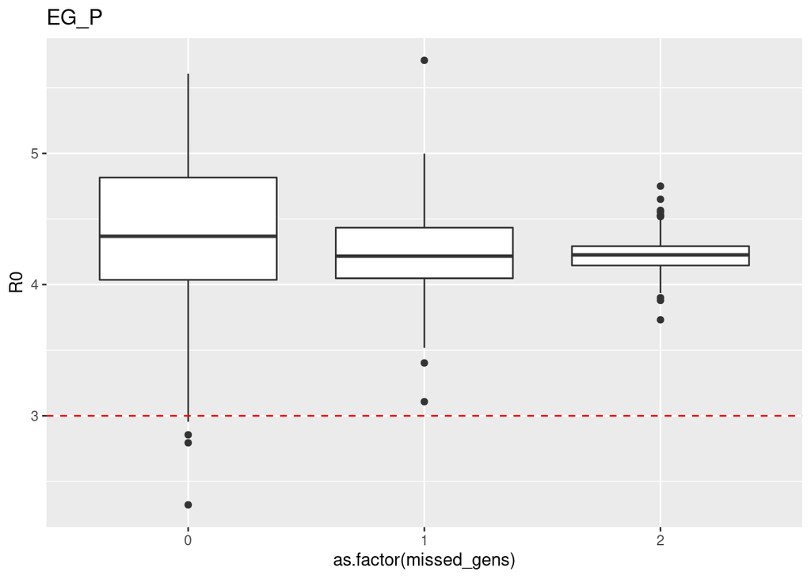

```r
df_egp <- filter(first_predictions, method == "EG_P")
ggplot(df_egp, aes(x = as.factor(missed_gens), y = R0)) + ggtitle("EG_P") +
  geom_boxplot() + geom_hline(yintercept = R_0, colour = "red", linetype="dashed")
```

[figure not shown]

```r
df_EpiEstim <- filter(first_predictions, method == "EpiEstim")
ggplot(df_eglin, aes(x = as.factor(missed_gens), y = R0)) +  ggtitle("EpiEstim") +
  geom_boxplot() + geom_hline(yintercept = R_0, colour = "red", linetype="dashed")
```

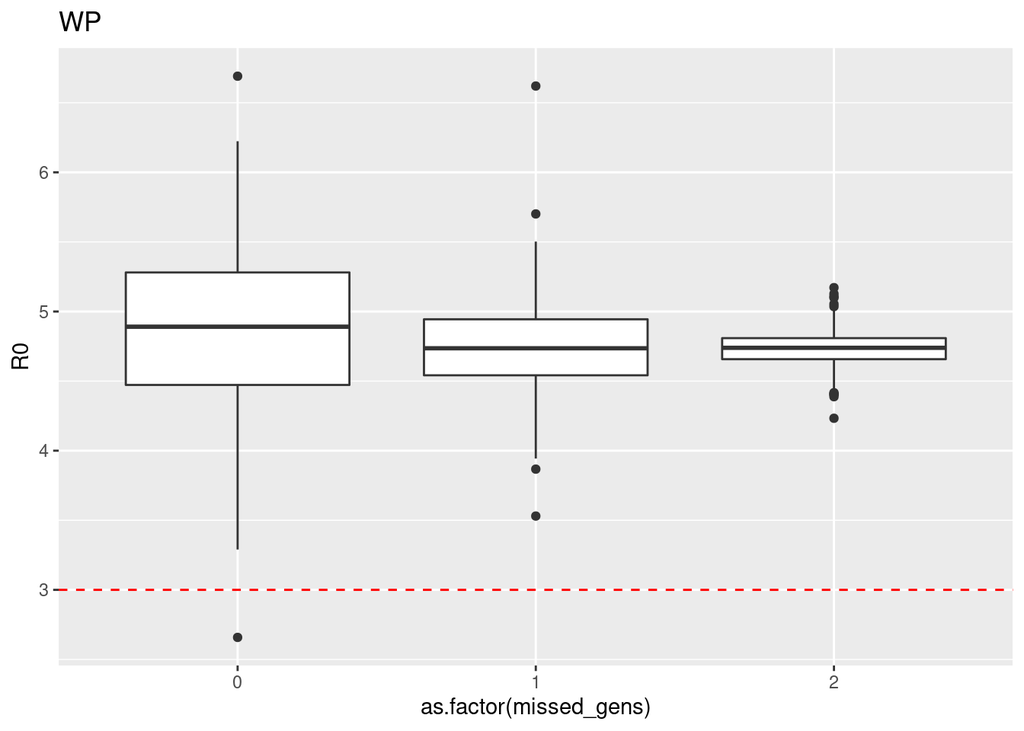

```r
df_WP <- filter(first_predictions, method == "WP")
ggplot(df_WP, aes(x = as.factor(missed_gens), y = R0)) +  ggtitle("WP") +
  geom_boxplot() + geom_hline(yintercept = R_0, colour = "red", linetype="dashed")
```

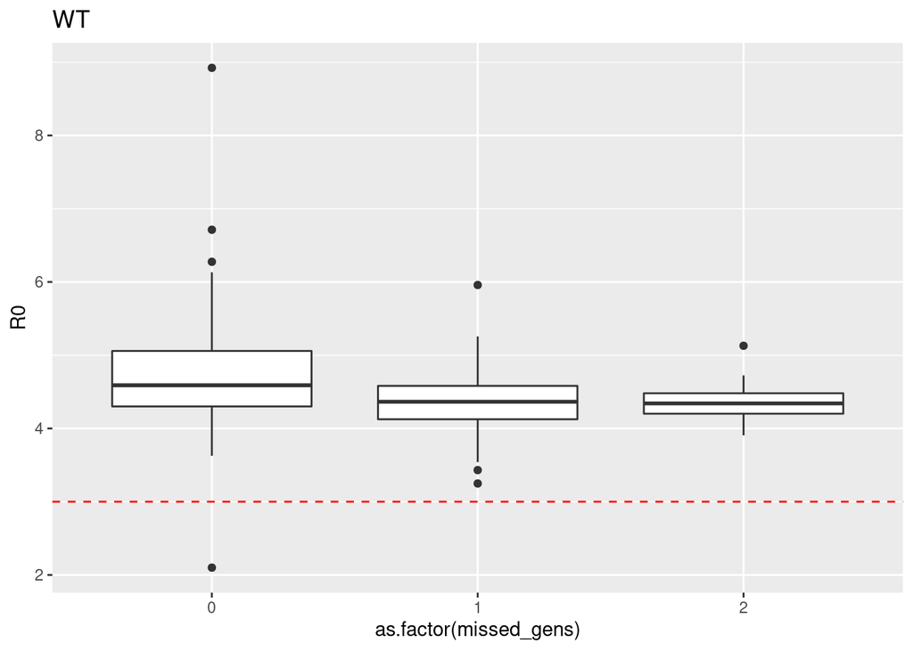

```r
df_WT <- filter(first_predictions, method == "WT")
ggplot(df_WT, aes(x = as.factor(missed_gens), y = R0)) + ggtitle("WT") +
  geom_boxplot() + geom_hline(yintercept = R_0, colour = "red", linetype="dashed")
```

[figure not shown]

```r
df_BR <- filter(first_predictions, method == "BR")
ggplot(df_WT, aes(x = as.factor(missed_gens), y = R0)) + ggtitle("BR") +
  geom_boxplot() + geom_hline(yintercept = R_0, colour = "red", linetype="dashed")
```

Every boxplot contains the same number of observations. Do we still see a decrease in variance with more missing generations?

And show them all together. The bias seems a little bit too large. Let us use all the data if $R_t$ is estimated more properly with the maximum number of data points

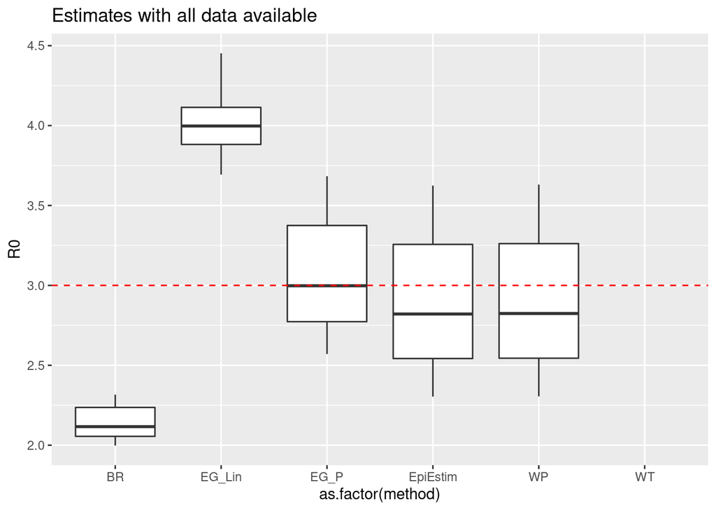

```r
final_predictions <- data.frame()

for (j in 1:params$n_sims){
    tmp <- as.data.frame(Sim_results[[1]][[j]])
    tmp <- tail(tmp, length(params$methods))
    final_predictions <- rbind(final_predictions, tmp)
}
final_predictions$R0 <- as.numeric(final_predictions$R0)
final_predictions$method <- unlist(final_predictions$method)

ggplot(final_predictions, aes(x = as.factor(method), y = R0)) + ggtitle("Estimates with all data available") +
  geom_boxplot() + geom_hline(yintercept = R_0, colour = "red", linetype="dashed")
```

### Coverage analysis

Check if real value is in the 95% interval.

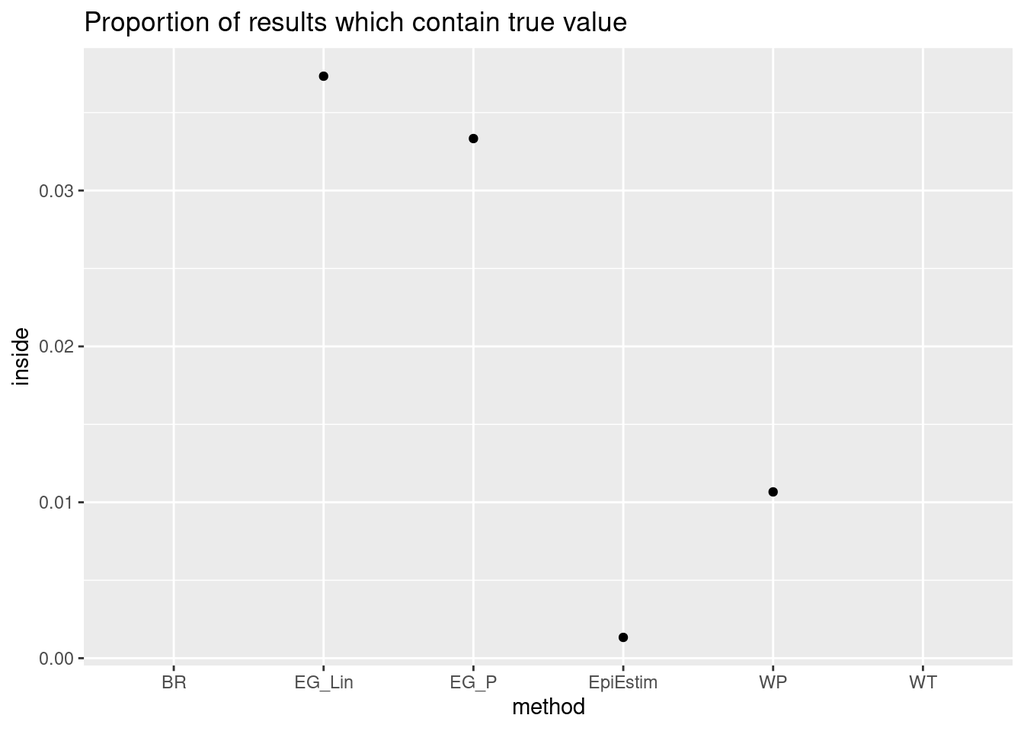

```r
CI = first_predictions %>% dplyr:::select(CI_L, CI_U, method)
CI$inside <- as.numeric(R_0 < CI$CI_U & R_0 > CI$CI_L)
CI$method <- as.factor(unlist(CI$method))
CI = CI %>% group_by(method) %>% summarise(inside = mean(inside))

ggplot(CI, aes(x = method ,y = inside, group = method )) + geom_point() + ggtitle('Proportion of results which contain true value')
```

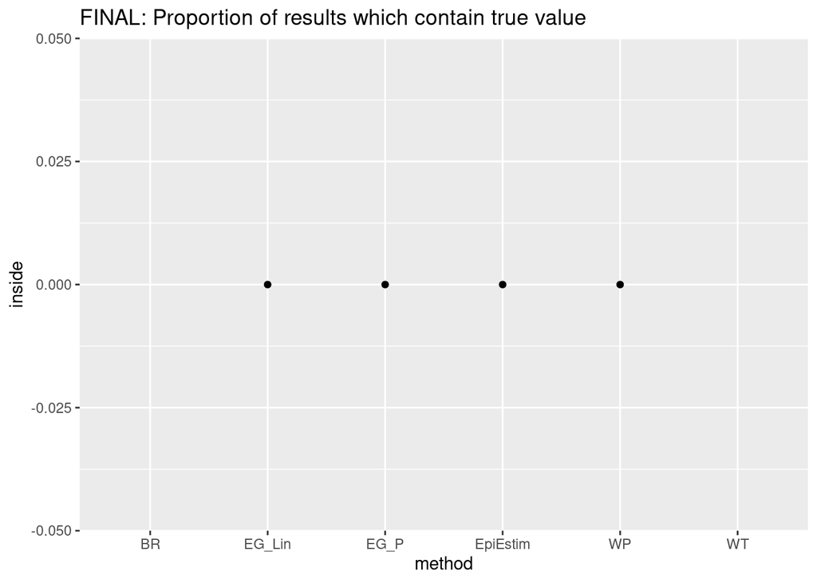

```r
CI_final = final_predictions %>% dplyr:::select(CI_L, CI_U, method)
CI_final$inside <- as.numeric(R_0 < CI_final$CI_U & R_0 > CI_final$CI_L)
CI_final$method <- as.factor(unlist(CI_final$method))
CI_final = CI_final %>% group_by(method) %>% summarise(inside = mean(inside))

ggplot(CI_final, aes(x = method ,y = inside, group = method )) + geom_point() + ggtitle('FINAL: Proportion of results which contain true value')
```

## Just a little maths: Probability of immediate extinction of the disease

While trying to play around with the simulations, I noted that even with $R_0 = 2$, quite a few simulations did not produce any new observations This corresponds to a case in which the epidemic dies out immediately.

How likely are we to observe such an event? Here I estimate this probability making use of a ‘random walk’ approximation.

List all infection and recovery events, and denote by $X_n$ the number of infected and exposed individuals at the time of the $n^{th}$ event ($X_n := E_n + I_n$). Now, the probability of an infection dying out correspond to the event $\{X_n = 0 \text{ eventually} \}$. Further, by the property of exponential random variables, we have:
$$\mathbb{P} [X_{n+1} = X_n + 1] = \mathbb{P} [\text{next event is } S \xrightarrow{} E] = \frac{ \beta I_n S_n }{\beta I_n S_n + \gamma I_n N}$$
Assuming a large population where the number of infections is negligible ($\frac{S_n}{N} \xrightarrow{} 1$ as $N \xrightarrow{} \infty$), we obtain:
$$\mathbb{P} [X_{n+1} = X_n + 1] \approx \pi := \frac{\beta}{\beta + \gamma} = \frac{R_0}{R_0 + 1}$$
Where we used the relationship between $\beta= R_0 \gamma$. Using this approximation, the probability of stepping up or down is constant, independent of $n$ and $X$. This allows us to compute the probability of extinction of the disease as a ruin probability:
$$p_k := P[X_n = 0 \text{ eventually } | X_0 = k] = \left( \frac{1-\pi}{\pi} \right)^k = R_0^{-k}$$
With $k = 10$ and $R_0 = 2$ this probability is around $1/1000$.

PS: it is true than in any epidemic with finite population $X_n = 0$ eventually, but this may be due to the fact that there is no one left to infect. In a “finite scenario”, I suggest to interpret the above probability as the probability of an epidemic dying out infecting a negligible part of the population.